# Lab4 Individual/Team

Colin Willenborg

10/11/2020

## Cleaning the data

```r
offClean <- offense %>%
  mutate_at(vars(Name,
            Opponent_Opponent),
            list(factor)) %>%
  separate('Passing_CMP-ATT', c('Passing_CMP', 'Passing_ATT'))%>%
  mutate(across(.cols = (Rushing_ATT:Passing_INT), .fns = (as.numeric)))

defClean <- defense %>%
  mutate_at(vars(Name,
            Opponent_Opponent),
            list(factor)) %>%
  mutate(across(.cols = (Tackles_Solo:Pass_PB), .fns = (as.numeric)))

bioClean <- biography %>%
  mutate_at(vars(Name),
            list(factor)) %>%
  mutate(Weight = as.numeric(Weight)) %>%
  separate(Height, c('feet', 'inches'), sep='-') %>%
  mutate(feet = as.numeric(feet), inches = as.numeric(inches)) %>%
  mutate(Height_inches = (12 * feet + inches)) %>%
  select(-feet, -inches)

str(offClean)
```

```
## tibble [195 x 13] (S3: tbl_df/tbl/data.frame)
##  $ Name             : Factor w/ 17 levels "Akers, Landen",..: 1 1 1 1 1 1 1 1 1 1 ...
##  $ Opponent_Opponent: Factor w/ 13 levels "Baylor","Iowa",..: 12 2 11 1 8 13 10 7 6 9 ...
##  $ Rushing_ATT      : num [1:195] 0 0 1 0 0 0 0 0 0 0 ...
##  $ Rushing_YDS      : num [1:195] 0 0 8 0 0 0 0 0 0 0 ...
##  $ Rushing_TD       : num [1:195] 0 0 0 0 0 0 0 0 0 0 ...
##  $ Receiving_REC    : num [1:195] 1 0 0 0 1 0 0 4 0 1 ...
##  $ Receiving_YDS    : num [1:195] 21 0 0 0 32 0 0 39 0 7 ...
##  $ Receiving_TD     : num [1:195] 0 0 0 0 0 0 0 0 0 0 ...
##  $ Passing_CMP      : num [1:195] NA NA NA NA NA NA NA NA NA NA ...
##  $ Passing_ATT      : num [1:195] NA NA NA NA NA NA NA NA NA NA ...
##  $ Passing_YDS      : num [1:195] NA NA NA NA NA NA NA NA NA NA ...
##  $ Passing_TD       : num [1:195] NA NA NA NA NA NA NA NA NA NA ...
##  $ Passing_INT      : num [1:195] NA NA NA NA NA NA NA NA NA NA ...
```

```r
str(defClean)
```

```
## tibble [502 x 11] (S3: tbl_df/tbl/data.frame)
##  $ Name             : Factor w/ 43 levels "Akers, Landen",..: 40 40 40 40 40 40 40 40 40 40 ...
##  $ Opponent_Opponent: Factor w/ 13 levels "Baylor","Iowa",..: 12 2 11 1 8 13 10 7 6 9 ...
##  $ Tackles_Solo     : num [1:502] 4 4 3 4 3 1 7 3 6 5 ...
##  $ Tackles_ASST     : num [1:502] 4 7 5 2 2 1 1 2 1 5 ...
##  $ Tackles_TFL      : num [1:502] 0 0 0 0 1 0 0 0 1 1 ...
##  $ Tackles_Sack     : num [1:502] 0 0 0 0 0 0 0 0 0 1 ...
##  $ Turnover_FF      : num [1:502] 0 0 0 0 0 0 0 0 0 0 ...
##  $ Turnover_FR      : num [1:502] 0 0 0 0 0 0 0 0 0 0 ...
##  $ Turnover_INT     : num [1:502] 0 0 1 0 0 0 0 0 1 0 ...
##  $ Pass_QBH         : num [1:502] 1 0 0 0 0 0 0 0 1 0 ...
##  $ Pass_PB          : num [1:502] 1 2 0 0 0 1 0 0 0 0 ...
```

```r
str(bioClean)
```

```
## tibble [105 x 7] (S3: tbl_df/tbl/data.frame)
##  $ Name         : Factor w/ 105 levels "Akers, Landen",..: 1 2 3 4 5 6 7 8 9 10 ...
##  $ Position     : chr [1:105] "Wide Receiver" "Tight End" "Wide Receiver" "Placekicker" ...
##  $ Weight       : num [1:105] 188 245 204 195 190 235 255 285 300 215 ...
##  $ Class        : chr [1:105] "Redshirt Senior" "Redshirt Senior" "Redshirt Freshman" "Redshirt Senior" ...
##  $ Hometown     : chr [1:105] "Cedar Rapids, Iowa" "Nixa, Mo." "Seffner, Fla." "Naperville, Ill." ...
##  $ Highschool   : chr [1:105] "Washington" "Nixa" "Armwood" "Central" ...
##  $ Height_inches: num [1:105] 72 79 77 72 72 75 74 74 72 78 ...
```

## Part 2: Tidying the data

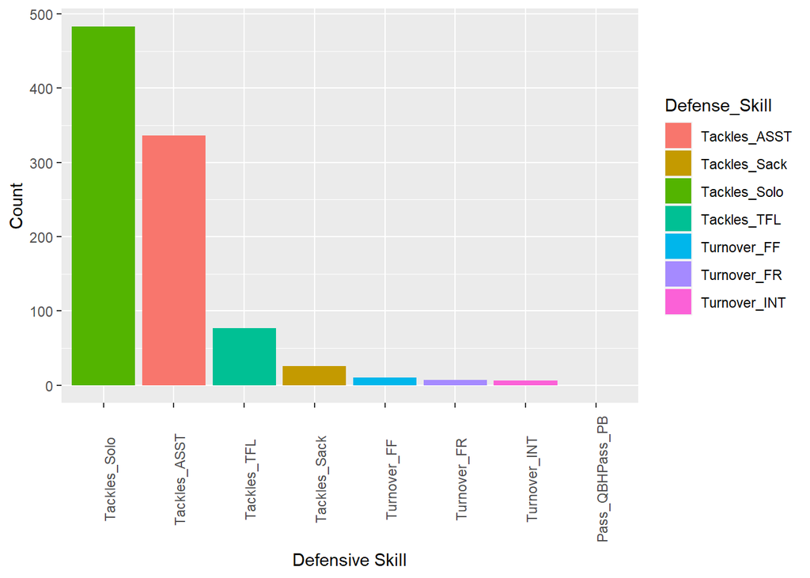

```r
defCleanPivot <- pivot_longer(defClean, Tackles_Solo:Pass_PB, names_to ="Defense_Skill", values_to = "stat")
skills <- c('Tackles_Solo', 'Tackles_ASST', 'Tackles_TFL',  'Tackles_Sack', 'Turnover_FF', 'Turnover_FR',   'Turnover_INT', 'Pass_QBH   Pass_PB')
ggplot(defCleanPivot, aes(x=Defense_Skill, y=stat, fill=Defense_Skill)) +
  geom_bar(stat= 'identity') + scale_x_discrete(limits = skills) +
  theme(axis.text.x = element_text(angle = 90)) + ylab("Count") +
  xlab("Defensive Skill")
```

The three rarest defensive skills in this dataset are fumble, fumble recovery, and interception.

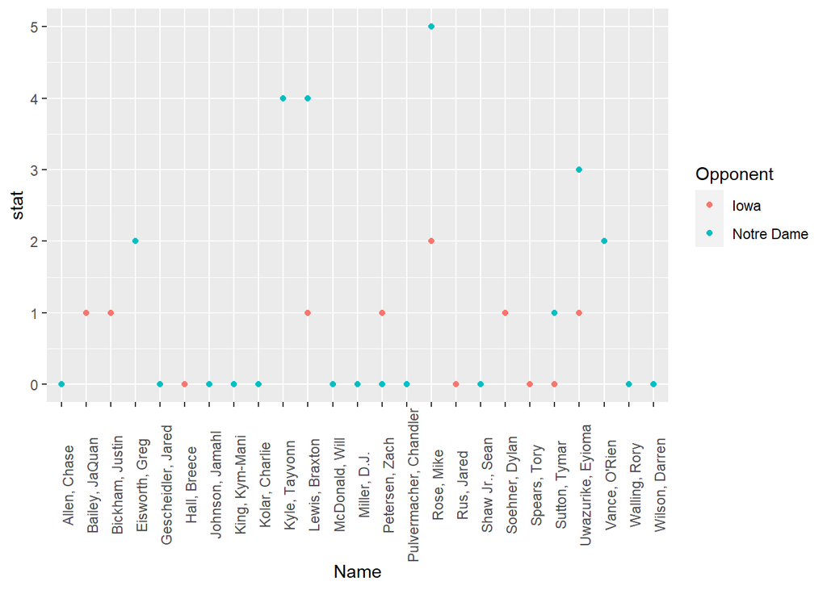

```r
defvsIowa <- defCleanPivot %>%
  filter(Opponent_Opponent == c('Iowa', 'Notre Dame'),
         Defense_Skill == 'Tackles_Solo')
ggplot(defvsIowa, aes(x=Name, y=stat, color=Opponent_Opponent)) +
  geom_point() + theme(axis.text.x = element_text(angle = 90)) + labs(color='Opponent')
```

```r
bioClean <- bioClean %>%
  separate(Hometown, c('City', 'State'), sep=',')
bioCleanState <- bioClean %>%
  select(State)
tableBio <- table(bioCleanState)
tableBio
```

```
## bioCleanState
##      Ariz.       Ark.  Australia     Calif.       Fla.        Ga.       Ill.
##          4          1          1          3         10          4          5
##       Iowa       Kan.      Mich.      Minn.      Miss.        Mo.       Ohio
##         35          3          4          4          1          6          7
##      Okla.        Pa.       S.D.      Texas       Wis.
##          2          1          2          6          6
```

## Part 3: Joining Data Frames

```r
offenseState <- left_join(offClean, bioClean, by='Name')
offenseState <- offenseState %>%
  select(Name, State) %>%
  unique()
offenseState <-offenseState %>%
  select(State)
offenseState <- table(offenseState)
offenseState
```

```
## offenseState
##  Ariz.   Ark.   Fla.    Ga.   Ill.   Iowa   Kan.    Mo.   Ohio  Okla.  Texas
##      1      1      2      1      1      1      1      1      1      2      1
```

```r
defenseState <- inner_join(defClean, bioClean, by='Name')
defenseState <- defenseState %>%
  select(Name, State) %>%
  unique()
defenseState
```

```
## # A tibble: 30 x 2
##    Name              State
##    <fct>             <chr>
##  1 White, Lawrence   " Calif."
##  2 Rose, Mike        " Ohio"
##  3 Vance, O'Rien     " Iowa"
##  4 Eisworth, Greg    " Texas"
##  5 Johnson , Anthony " Fla."
##  6 Petersen, Zach    " Iowa"
##  7 Hummel, Jake      " Iowa"
##  8 Uwazurike, Eyioma " Mich."
##  9 Azunna, Arnold    " Texas"
## 10 Kyle, Tayvonn     " Ga."
## # ... with 20 more rows
```

```r
defenseState <- defenseState %>%
  select(State)
defenseStateTable <- table(defenseState)
defenseStateTable
```

```
## defenseState
##    Ark.  Calif.    Fla.     Ga.    Iowa    Kan.   Mich.     Mo.    Ohio   Okla.
##       1       2       4       3       7       1       1       2       3       2
##   Texas    Wis.
##       2       2
```

For the offense data set there are 4 players who have no Biography data so wanted to say that here before going into the analysis. The offense has fewer players to look at but it is very spread out with the most of 2 being from one state both from Florida and Oklahoma. On the other hand defense has multiple states with a lot of players from them and has 7 home grown players from Iowa.

```r
wins <- c('UNI', 'ULM', 'TCU', 'West Virginia', 'Texas Tech', 'Texas', 'Kansas')
offCleanPurdy <- offClean %>%
  filter(Name == "Purdy, Brock") %>%
  select(-Receiving_REC, -Receiving_TD, -Receiving_YDS) %>%
  mutate(QB_Rating = (Passing_CMP/Passing_ATT) + (3.3 * (Passing_TD/Passing_ATT) -(2*(Passing_INT/Passing_ATT)) + (8.4 * Passing_YDS/Passing_ATT))) %>%
  mutate(Win = ifelse(Opponent_Opponent %in% wins, 'W', 'L')) %>%
  arrange(QB_Rating) %>%
  select(Name, Opponent_Opponent, QB_Rating, Win)
offCleanPurdy
```

```
## # A tibble: 13 x 4
##    Name         Opponent_Opponent QB_Rating Win
##    <fct>        <fct>                 <dbl> <chr>
##  1 Purdy, Brock Oklahoma State         52.3 L
##  2 Purdy, Brock Kansas State           52.4 L
##  3 Purdy, Brock UNI                    57.8 W
##  4 Purdy, Brock Texas                  62.7 W
##  5 Purdy, Brock Notre Dame             62.7 L
##  6 Purdy, Brock Baylor                 64.5 L
##  7 Purdy, Brock West Virginia          64.8 W
##  8 Purdy, Brock Iowa                   69.0 L
##  9 Purdy, Brock Kansas                 75.4 W
## 10 Purdy, Brock Oklahoma               80.1 L
## 11 Purdy, Brock TCU                    87.5 W
## 12 Purdy, Brock Texas Tech            100.  W
## 13 Purdy, Brock ULM                   136.  W
```

I followed a formula to find the NCAA Quarterback Rating and then arranged the table by that. This shows that when Purdy is performing ISU wins games. He won 5 of the top 7 games for his QB_Rating. So when he performs ISU does well.

Defense analysis

```r
defense18 <- read_excel('./cyclonesFootball2018.xlsx', sheet='Defensive')

defClean2018Name <- defense18 %>% select(Name) %>% distinct()
defClean2019Name <- defClean %>% select(Name) %>% distinct()
namesDefense <- inner_join(defClean2019Name, defClean2018Name, by='Name')

defClean2018 <- defense18 %>%
  mutate_at(vars(Name,
            Opponent_Opponent),
            list(factor)) %>%
  mutate(across(.cols = (Tackles_Solo:Pass_PB), .fns = (as.numeric))) %>%
  group_by(Name) %>%
  summarise_at(vars(Tackles_Solo:Pass_PB), sum, na.rm=TRUE) %>%
  mutate(Year = 2018) %>%
  right_join(namesDefense) %>%
  pivot_longer('Tackles_Solo':'Pass_PB', names_to='Defense_Skill', values_to='stat')
defClean2019 <- defClean %>%
  select(-Opponent_Opponent) %>%
  group_by(Name) %>%
  summarise_at(vars(Tackles_Solo:Pass_PB), sum, na.rm=TRUE) %>%
  mutate(Year = 2019) %>%
  right_join(namesDefense) %>%
  pivot_longer('Tackles_Solo':'Pass_PB', names_to='Defense_Skill', values_to='stat')
def2018_2019 <- full_join(defClean2018, defClean2019)
```

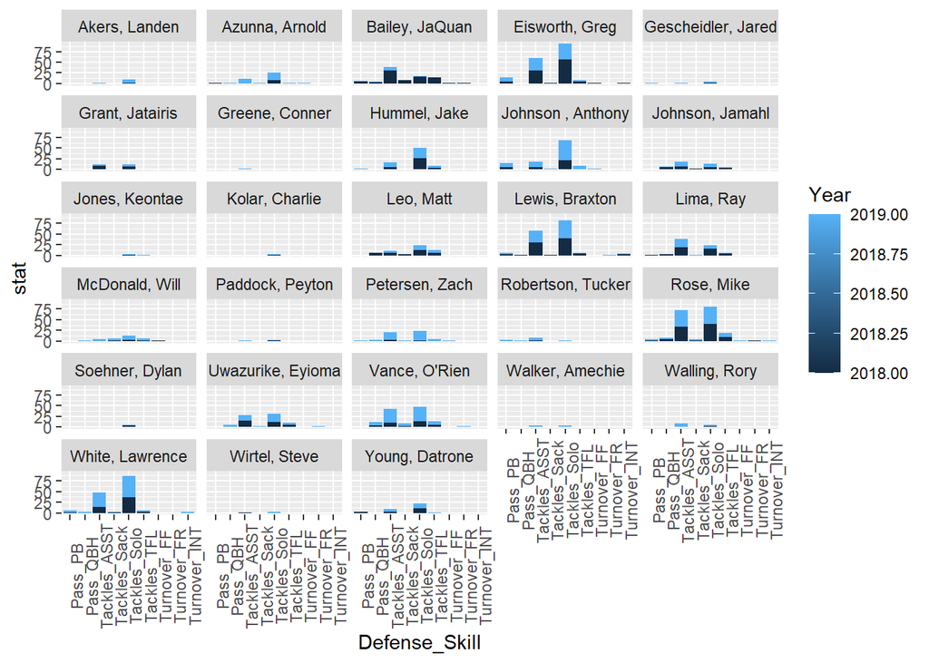

```r
ggplot(def2018_2019, aes(x=Defense_Skill, y=stat, fill=Year)) +
  geom_bar(stat='identity') +
  theme(axis.text.x = element_text(angle=90)) +
  facet_wrap(~Name, 6)
```

```r
def2018_2019new <- def2018_2019[def2018_2019$Name == 'Bailey, JaQuan' | def2018_2019$Name == 'Eisworth, Greg' | def2018_2019$Name == 'Lewis, Braxton' |
                             def2018_2019$Name == 'Hummel, Jake' | def2018_2019$Name == 'Johnson, Anthony' | def2018_2019$Name == 'Rose, Mike' |
                             def2018_2019$Name == 'Uwazurike, Eyioma' | def2018_2019$Name == "Vance, O'Rien" | def2018_2019$Name == 'White, Lawrence',]
def2018_2019new
```

```
## # A tibble: 144 x 4
##    Name            Year Defense_Skill  stat
##    <chr>          <dbl> <chr>         <dbl>
##  1 Bailey, JaQuan  2018 Tackles_Solo   16
##  2 Bailey, JaQuan  2018 Tackles_ASST   30
##  3 Bailey, JaQuan  2018 Tackles_TFL    14.5
##  4 Bailey, JaQuan  2018 Tackles_Sack    8
##  5 Bailey, JaQuan  2018 Turnover_FF     1
##  6 Bailey, JaQuan  2018 Turnover_FR     1
##  7 Bailey, JaQuan  2018 Turnover_INT    0
##  8 Bailey, JaQuan  2018 Pass_QBH        3
##  9 Bailey, JaQuan  2018 Pass_PB         5
## 10 Eisworth, Greg  2018 Tackles_Solo   56
## # ... with 134 more rows
```

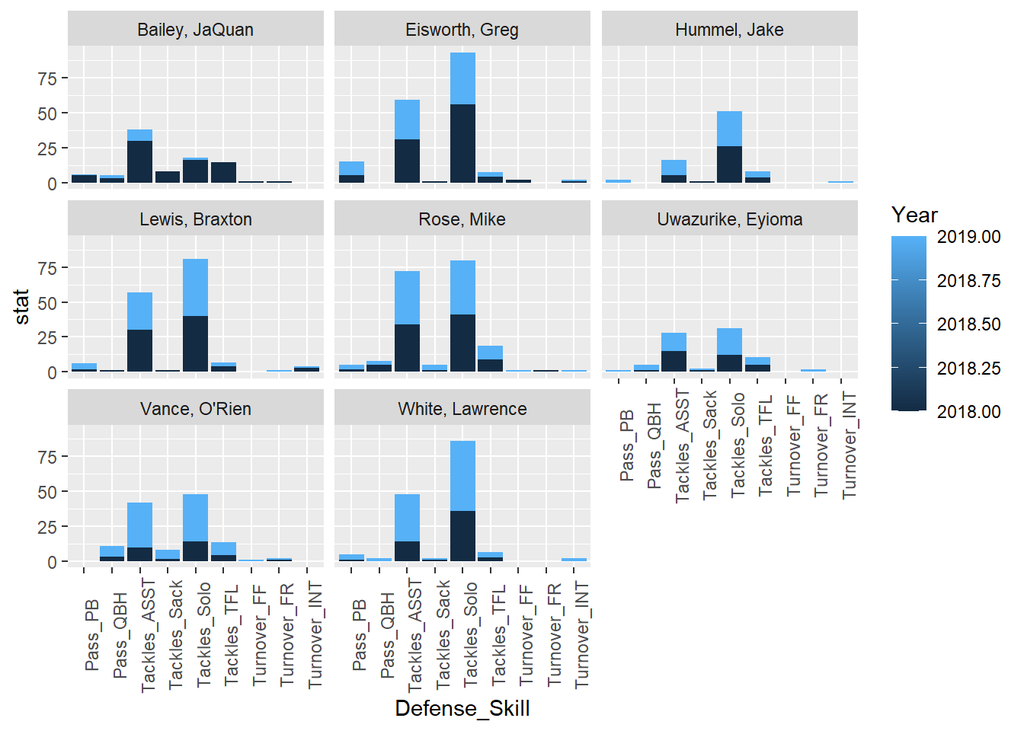

```r
ggplot(def2018_2019new, aes(x=Defense_Skill, y=stat, fill=Year)) +
  geom_bar(stat='identity') +
  theme(axis.text.x = element_text(angle=90)) +
  facet_wrap(~Name)
```

For the defense players I first looked at all the players and then I took the biggest graphs from that and put them in a new data frame to analize them easier. This shows that the most improved player defensively would have been between Mike Rose, Lawerence White, and Greg Eisworth.

```r
offense18 <- read_excel('./cyclonesFootball2018.xlsx', sheet='Offensive')

offClean2018Name <- offense18 %>% select(Name) %>% distinct()
offClean2019Name <- offClean %>% select(Name) %>% distinct()
namesOffense <- inner_join(offClean2018Name, offClean2019Name, by='Name')

offClean2018 <- offense18 %>%
  mutate_at(vars(Name,
            Opponent_Opponent),
            list(factor)) %>%
  mutate(across(.cols = (Rushing_ATT:Receiving_TD), .fns = (as.numeric))) %>%
  group_by(Name) %>%
  summarise_at(vars(Rushing_ATT:Receiving_TD), sum, na.rm=TRUE) %>%
  mutate(Year = 2018) %>%
  filter(Name != 'Purdy, Brock') %>%
  right_join(namesOffense) %>%
  pivot_longer('Rushing_ATT':'Receiving_TD', names_to='Offense_Skill', values_to='stat')
offClean2019 <- offClean %>%
  select(-Opponent_Opponent) %>%
  group_by(Name) %>%
  summarise_at(vars(Rushing_ATT:Receiving_TD), sum, na.rm=TRUE) %>%
  mutate(Year = 2019) %>%
  filter(Name != 'Purdy, Brock') %>%
  right_join(namesOffense) %>%
  pivot_longer('Rushing_ATT':'Receiving_TD', names_to='Offense_Skill', values_to='stat')
off2018_2019 <- full_join(offClean2018, offClean2019)
```

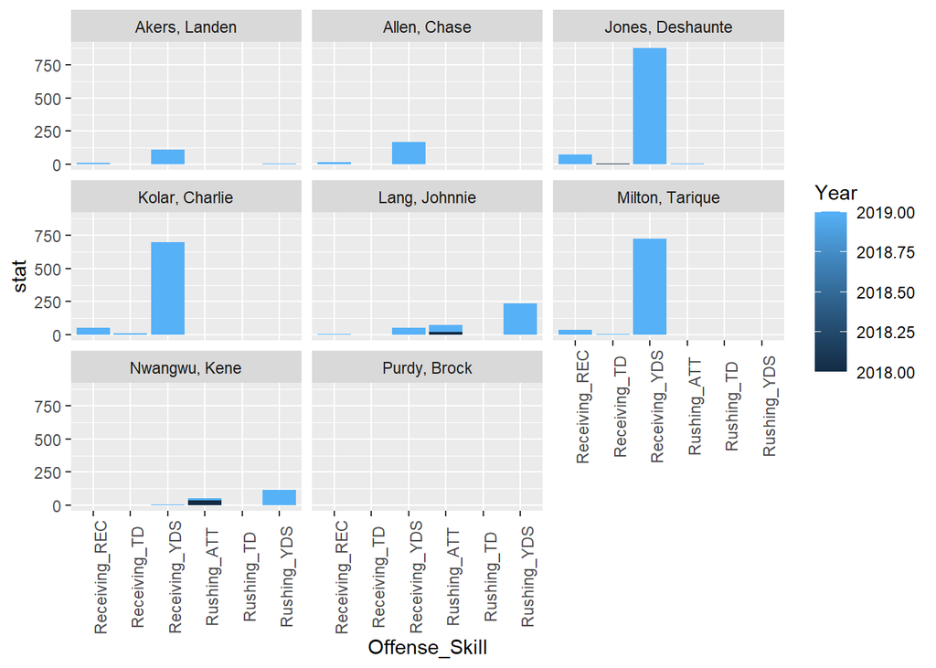

```r
ggplot(off2018_2019, aes(x=Offense_Skill, y=stat, fill=Year)) +
  geom_bar(stat='identity') +
  theme(axis.text.x = element_text(angle=90)) +
  facet_wrap(~Name)
```

```r
offClean2018 <- offense18 %>%
  mutate_at(vars(Name,
            Opponent_Opponent),
            list(factor)) %>%
  separate('Passing_CMP-ATT', c('Passing_CMP', 'Passing_ATT'))%>%
  mutate(across(.cols = ('Passing_CMP':Passing_INT), .fns = (as.numeric))) %>%
  group_by(Name) %>%
  summarise_at(vars('Passing_CMP':Passing_INT), sum, na.rm=TRUE) %>%
  mutate(Year = 2018) %>%
  right_join(namesOffense) %>%
  pivot_longer('Passing_CMP':'Passing_INT', names_to='Offense_Skill', values_to='stat')
offClean2019 <- offClean %>%
  select(-Opponent_Opponent) %>%
  group_by(Name) %>%
  summarise_at(vars('Passing_CMP':Passing_INT), sum, na.rm=TRUE) %>%
  mutate(Year = 2019) %>%
  right_join(namesOffense) %>%
  pivot_longer('Passing_CMP':'Passing_INT', names_to='Offense_Skill', values_to='stat')
off2018_2019 <- full_join(offClean2018, offClean2019)
```

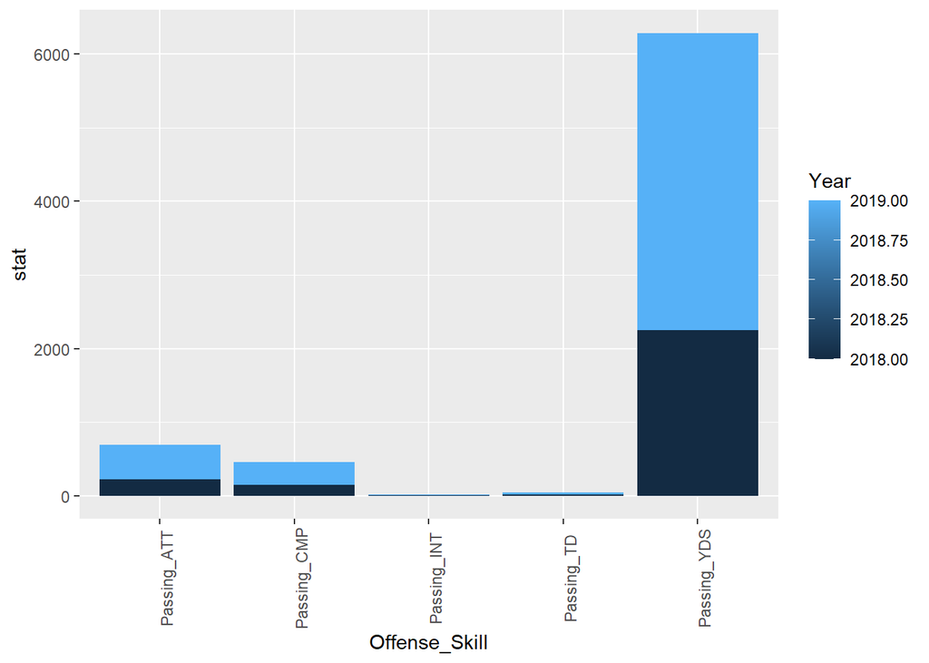

```r
off2018_2019 <- off2018_2019[Name="Purdy, Brock", ]

ggplot(off2018_2019, aes(x=Offense_Skill, y=stat, fill=Year)) +
  geom_bar(stat='identity') +
  theme(axis.text.x = element_text(angle=90))
```

For the offense I looked at both the offensive players not including Purdy and then looked at Purdy seperately. It shows that Purdy improved a lot from 2018 to 2019 and is one of the most improved players but some of the other players also improved a lot. Deshaunte Jones is an example of a really big improvement from 2018 barely playing to being one of our best receivers in the 2019 season.